# MIMIC Project: Relative Hypoglycemia (Analysis)

# Conclusion 1: RH is harmful in non diabetic patient with high initial glucose level

```r
main$dm <- as.factor(main$dm)
gluclookup <- c("[  60, 150)"="Glucose 60-150", "[ 150, 200)"="Glucose 150-200",
                "[ 200, 300)"="Glucose 200-300", "[ 300,2340]"="First Glucose > 300")
anyhypolookup <- c("FALSE"="All Glucose > 60", "TRUE"="One or more Glucose < 60 ")

glucbypd2 <- main %>% filter(!is.na(glucgt200)) %>%
  mutate(hasRH=proprh > 0) %>% group_by(hasRH, dm, anyhypo=anyhypo > 0, glucgt200) %>%
  summarise(n=n(), medianICULOS=median(icu_los,na.rm=T),
            mort28Rate=mean(mort28), mort28SE=sqrt(mort28Rate*(1-mort28Rate)/n),
            mort90Rate=mean(mort90), mort90SE=sqrt(mort90Rate*(1-mort90Rate)/n),
            mort365Rate=mean(mort365), mort365SE=sqrt(mort365Rate*(1-mort365Rate)/n))

p <- ggplot(glucbypd2, aes(hasRH, mort28Rate, group=dm, color=dm)) +
  geom_line() +
  geom_ribbon(aes(ymax=mort28Rate + qnorm(0.975) * mort28SE,
                  ymin=mort28Rate - qnorm(0.975) * mort28SE, color=dm, fill=dm)
              ,alpha=0.2, linetype=0) +
  xlab("Has Test with RH") + ylab("28 Day Mortality Rate") +
  facet_grid(anyhypo ~ glucgt200, labeller = labeller(.default = capitalize, glucgt200 = gluclookup,
                                                      anyhypo=anyhypolookup))

ggplotly(p + theme(axis.title = NULL, legend.direction="vertical", legend.position="right") +
           scale_fill_fivethirtyeight() +
           scale_color_fivethirtyeight() +
           geom_text(data=glucbypd2, aes(label=n), size=3))
```

[interactive chart not shown]

```r
# 28-day
glucOR <- split(glucbypd2,glucbypd2$hasRH)[[1]] %>%
  inner_join(split(glucbypd2, glucbypd2$hasRH)[[2]],
             by=c("dm"="dm", "anyhypo"="anyhypo", "glucgt200"="glucgt200")) %>%
  group_by(dm,anyhypo,glucgt200) %>%
  summarise(c=n.x*mort28Rate.x, d=n.x*(1-mort28Rate.x), a=n.y*mort28Rate.y,
            b=n.y*(1-mort28Rate.y), OR=(a*d)/(c*b), SE=sqrt(1/a+1/b+1/c+1/d),
            ORL= exp(log(OR) - qnorm(0.975)*SE), ORU= exp(log(OR) + qnorm(0.975)*SE))

p <- ggplot(glucOR, aes(dm,OR,colour=as.factor(dm))) +
  facet_grid(anyhypo ~ glucgt200, labeller = labeller(.default = capitalize,
                                                      glucgt200 = gluclookup, anyhypo=anyhypolookup)) +
  geom_point() + xlab("Diabetes") + ylab("OR of [RH -> mortality]") +
  geom_errorbar(aes(ymax=ORU,ymin=ORL), size=0.8, width=0.1) +
  geom_hline(aes(yintercept=1), linetype=3) +
  annotate("text", x = 1.5, y = 1.5, label = "Higher Mortality", alpha=0.5, size=3) +
  annotate("text", x = 1.5, y = 0.75, label = "Lower Mortality", alpha=0.5, size=3) +
  scale_color_discrete(guide = guide_legend(title="Diabetes", labels=c("Non-Diabetic","Diabetic"))) +
  ggtitle("28 Day Mortality")

ggplotly(p + theme(axis.title = NULL, legend.direction="vertical", legend.position="right") +
           scale_fill_fivethirtyeight() + scale_color_fivethirtyeight())
```

[interactive chart not shown]

```r
# 90-day
glucOR <- split(glucbypd2,glucbypd2$hasRH)[[1]] %>%
  inner_join(split(glucbypd2, glucbypd2$hasRH)[[2]],
             by=c("dm"="dm", "anyhypo"="anyhypo", "glucgt200"="glucgt200")) %>%
  group_by(dm,anyhypo,glucgt200) %>%
  summarise(c=n.x*mort90Rate.x, d=n.x*(1-mort90Rate.x), a=n.y*mort90Rate.y,
            b=n.y*(1-mort90Rate.y), OR=(a*d)/(c*b), SE=sqrt(1/a+1/b+1/c+1/d),
            ORL= exp(log(OR) - qnorm(0.975)*SE), ORU= exp(log(OR) + qnorm(0.975)*SE))

p <- ggplot(glucOR, aes(dm,OR,colour=as.factor(dm))) +
  facet_grid(anyhypo ~ glucgt200, labeller = labeller(.default = capitalize,
                                                      glucgt200 = gluclookup, anyhypo=anyhypolookup)) +
  geom_point() + xlab("Diabetes") + ylab("OR of [RH -> mortality]") +
  geom_errorbar(aes(ymax=ORU,ymin=ORL), size=0.8, width=0.1) +
  geom_hline(aes(yintercept=1), linetype=3) +
  annotate("text", x = 1.5, y = 1.5, label = "Higher Mortality", alpha=0.5, size=3) +
  annotate("text", x = 1.5, y = 0.75, label = "Lower Mortality", alpha=0.5, size=3) +
  scale_color_discrete(guide = guide_legend(title="Diabetes", labels=c("Non-Diabetic","Diabetic"))) +
  ggtitle("90 Day Mortality")

ggplotly(p + theme(axis.title = NULL, legend.direction="vertical", legend.position="right") +
           scale_fill_fivethirtyeight() + scale_color_fivethirtyeight())
```

[interactive chart not shown]

```r
#365-day
glucOR <- split(glucbypd2,glucbypd2$hasRH)[[1]] %>%
  inner_join(split(glucbypd2, glucbypd2$hasRH)[[2]],
             by=c("dm"="dm", "anyhypo"="anyhypo", "glucgt200"="glucgt200")) %>%
  group_by(dm,anyhypo,glucgt200) %>%
  summarise(c=n.x*mort365Rate.x, d=n.x*(1-mort365Rate.x), a=n.y*mort365Rate.y,
            b=n.y*(1-mort365Rate.y), OR=(a*d)/(c*b), SE=sqrt(1/a+1/b+1/c+1/d),
            ORL= exp(log(OR) - qnorm(0.975)*SE), ORU= exp(log(OR) + qnorm(0.975)*SE))

p <- ggplot(glucOR, aes(dm,OR,colour=as.factor(dm))) +
  facet_grid(anyhypo ~ glucgt200, labeller = labeller(.default = capitalize,
                                                      glucgt200 = gluclookup, anyhypo=anyhypolookup)) +
  geom_point() + xlab("Diabetes") + ylab("OR of [RH -> mortality]") +
  geom_errorbar(aes(ymax=ORU,ymin=ORL), size=0.8, width=0.1) +
  geom_hline(aes(yintercept=1), linetype=3) +
  annotate("text", x = 1.5, y = 1.5, label = "Higher Mortality", alpha=0.5, size=3) +
  annotate("text", x = 1.5, y = 0.75, label = "Lower Mortality", alpha=0.5, size=3) +
  scale_color_discrete(guide = guide_legend(title="Diabetes", labels=c("Non-Diabetic","Diabetic"))) +
  ggtitle("365 Day Mortality")

ggplotly(p + theme(axis.title = NULL, legend.direction="vertical", legend.position="right") +
           scale_fill_fivethirtyeight() + scale_color_fivethirtyeight())
```

[interactive chart not shown]

# Conclusion 2: RH has dosage effect on the mortality of non diabetic patients with high initial glucose level

- Probably we can remove diabetic group from this part.
- Discussion: Frequent RH also leads to higher glucose variability.

```r
main <- main[main$dm == 0, ]
glucbypd3 <- main %>% filter(!is.na(glucgt200)) %>%
  mutate(hasRH=cut2(proprh, c(0.05, 0.15, 0.25))) %>% group_by(hasRH, dm, anyhypo=anyhypo > 0, glucgt200) %>%
  summarise(n=n(), medianICULOS=median(icu_los,na.rm=T),
            mort28Rate=mean(mort28), mort28SE=sqrt(mort28Rate*(1-mort28Rate)/n),
            mort90Rate=mean(mort90), mort90SE=sqrt(mort90Rate*(1-mort90Rate)/n),
            mort365Rate=mean(mort365), mort365SE=sqrt(mort365Rate*(1-mort365Rate)/n))

p <- ggplot(glucbypd3, aes(hasRH, mort28Rate, group=dm, color=dm)) +
  geom_line() +
  geom_ribbon(aes(ymax=mort28Rate + qnorm(0.975) * mort28SE,
                  ymin=mort28Rate - qnorm(0.975) * mort28SE, color=dm, fill=dm)
              ,alpha=0.2, linetype=0) +
  xlab("Proportion of RH") + ylab("28 Day Mortality Rate") +
  facet_grid(anyhypo ~ glucgt200, labeller = labeller(.default = capitalize, glucgt200 = gluclookup,
                                                      anyhypo=anyhypolookup))

ggplotly(p + theme(axis.title = NULL, legend.direction="vertical", legend.position="right") +
           scale_fill_fivethirtyeight() +
           scale_color_fivethirtyeight() +
           geom_text(data=glucbypd3, aes(label=n), size=3))
```

[interactive chart not shown]

# Conclusion 3: Insulin administration is associated with higher mortality rate in non diabetic population

- Figure 3. Insulin type in the cohort. (some items are ambiguous and we couldn’t identify if they are IV or SC)
- Considering binary insulin administration, non diabetic group with RH has higher mortality rate in insulin group and lower mortality in the group without insulin administration.
- Higher initial glucose level in non diabetic patients associates with higher mortality rate.
- However, the risk of RH -> mortality is not significant (in fact, no insulin group seems has higher OR).
- Discussion: Insulin may cause drastic drop of blood sugar and lead to higher glucose variability

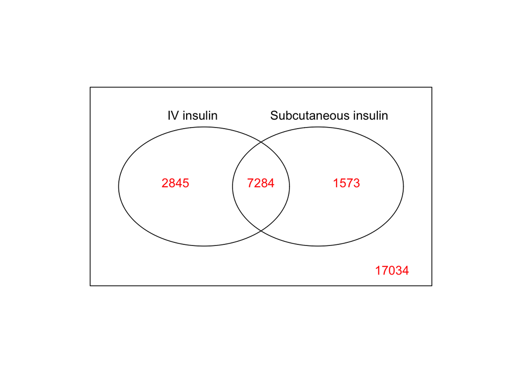

[interactive chart not shown]

```r
limma::vennDiagram(limma::vennCounts(main[, c("ins_iv", "ins_sc")]),
                   include = "both", names = c("IV insulin", "Subcutaneous insulin"),
                   cex = 1, counts.col = "red")

insulinlookup <- c("FALSE"="No insulin", "TRUE"="With insulin")
gluclookup <- c("[  60, 150)"="Glucose 60-150", "[ 150, 200)"="Glucose 150-200",
                "[ 200, 300)"="Glucose 200-300", "[ 300,2340]"="First Glucose > 300")

glucbypd4 <- main %>% filter(!is.na(ins_mean)) %>%
  mutate(hasRH=proprh > 0) %>% group_by(hasRH, dm, anyhypo=anyhypo > 0, ins=ins_mean > 0, glucgt200) %>%
  summarise(n=n(), medianICULOS=median(icu_los,na.rm=T),
            mort28Rate=mean(mort28), mort28SE=sqrt(mort28Rate*(1-mort28Rate)/n),
            mort90Rate=mean(mort90), mort90SE=sqrt(mort90Rate*(1-mort90Rate)/n),
            mort365Rate=mean(mort365), mort365SE=sqrt(mort365Rate*(1-mort365Rate)/n))
glucbypd4 <- na.omit(glucbypd4)

p <- ggplot(glucbypd4, aes(hasRH, mort28Rate, group=dm, color=dm)) +
  geom_line() +
  geom_ribbon(aes(ymax=mort28Rate + qnorm(0.975) * mort28SE,
                  ymin=mort28Rate - qnorm(0.975) * mort28SE, color=dm, fill=dm)
              ,alpha=0.2, linetype=0) +
  xlab("Has Test with RH") + ylab("28 Day Mortality Rate") +
  facet_grid(ins ~ glucgt200, labeller = labeller(.default = capitalize, glucgt200 = gluclookup,
                                                      ins=insulinlookup))

ggplotly(p + theme(axis.title = NULL, legend.direction="vertical", legend.position="right") +
           scale_fill_fivethirtyeight() +
           scale_color_fivethirtyeight() +
           geom_text(data=glucbypd4, aes(label=n), size=3))
```

```r
# 28-day
glucOR <- split(glucbypd4, glucbypd4$hasRH)[[1]] %>%
  inner_join(split(glucbypd4, glucbypd4$hasRH)[[2]],
             by=c("dm"="dm", "glucgt200"="glucgt200", "ins"="ins")) %>%
  group_by(dm, glucgt200, ins) %>%
  summarise(c=n.x*mort28Rate.x, d=n.x*(1-mort28Rate.x), a=n.y*mort28Rate.y,
            b=n.y*(1-mort28Rate.y), OR=(a*d)/(c*b), SE=sqrt(1/a+1/b+1/c+1/d),
            ORL= exp(log(OR) - qnorm(0.975)*SE), ORU= exp(log(OR) + qnorm(0.975)*SE))

p <- ggplot(glucOR, aes(dm,OR,colour=as.factor(dm))) +
  facet_grid(ins ~ glucgt200, labeller = labeller(.default = capitalize, glucgt200 = gluclookup,
                                                      ins = insulinlookup)) +
  geom_point() + xlab("Diabetes") + ylab("OR") +
  geom_errorbar(aes(ymax=ORU,ymin=ORL), size=0.8, width=0.1) +
  geom_hline(aes(yintercept=1), linetype=3) +
  annotate("text", x = 1.5, y = 1.5, label = "Higher Mortality", alpha=0.5, size=3) +
  annotate("text", x = 1.5, y = 0.75, label = "Lower Mortality", alpha=0.5, size=3) +
  scale_color_discrete(guide = guide_legend(title="Diabetes", labels=c("Non-Diabetic","Diabetic"))) +
  ggtitle("28 Day Mortality")

ggplotly(p + theme(axis.title = NULL, legend.direction="vertical", legend.position="right") +
           scale_fill_fivethirtyeight() + scale_color_fivethirtyeight())
```

[interactive chart not shown]

```r
# 90-day
glucOR <- split(glucbypd4, glucbypd4$hasRH)[[1]] %>%
  inner_join(split(glucbypd4, glucbypd4$hasRH)[[2]],
             by=c("dm"="dm", "glucgt200"="glucgt200", "ins"="ins")) %>%
  group_by(dm, glucgt200, ins) %>%
  summarise(c=n.x*mort90Rate.x, d=n.x*(1-mort90Rate.x), a=n.y*mort90Rate.y,
            b=n.y*(1-mort90Rate.y), OR=(a*d)/(c*b), SE=sqrt(1/a+1/b+1/c+1/d),
            ORL= exp(log(OR) - qnorm(0.975)*SE), ORU= exp(log(OR) + qnorm(0.975)*SE))

p <- ggplot(glucOR, aes(dm,OR,colour=as.factor(dm))) +
  facet_grid(ins ~ glucgt200, labeller = labeller(.default = capitalize,
                                                      ins = insulinlookup, glucgt200 = gluclookup)) +
  geom_point() + xlab("Diabetes") + ylab("OR") +
  geom_errorbar(aes(ymax=ORU,ymin=ORL), size=0.8, width=0.1) +
  geom_hline(aes(yintercept=1), linetype=3) +
  annotate("text", x = 1.5, y = 1.5, label = "Higher Mortality", alpha=0.5, size=3) +
  annotate("text", x = 1.5, y = 0.75, label = "Lower Mortality", alpha=0.5, size=3) +
  scale_color_discrete(guide = guide_legend(title="Diabetes", labels=c("Non-Diabetic","Diabetic"))) +
  ggtitle("90 Day Mortality")

ggplotly(p + theme(axis.title = NULL, legend.direction="vertical", legend.position="right") +
           scale_fill_fivethirtyeight() + scale_color_fivethirtyeight())
```

[interactive chart not shown]

```r
# 365-day
glucOR <- split(glucbypd4, glucbypd4$hasRH)[[1]] %>%
  inner_join(split(glucbypd4, glucbypd4$hasRH)[[2]],
             by=c("dm"="dm", "glucgt200"="glucgt200", "ins"="ins")) %>%
  group_by(dm, glucgt200, ins) %>%
  summarise(c=n.x*mort365Rate.x, d=n.x*(1-mort365Rate.x), a=n.y*mort365Rate.y,
            b=n.y*(1-mort365Rate.y), OR=(a*d)/(c*b), SE=sqrt(1/a+1/b+1/c+1/d),
            ORL= exp(log(OR) - qnorm(0.975)*SE), ORU= exp(log(OR) + qnorm(0.975)*SE))

p <- ggplot(glucOR, aes(dm,OR,colour=as.factor(dm))) +
  facet_grid(ins ~ glucgt200, labeller = labeller(.default = capitalize,
                                                      ins = insulinlookup, glucgt200=gluclookup)) +
  geom_point() + xlab("Diabetes") + ylab("OR") +
  geom_errorbar(aes(ymax=ORU,ymin=ORL), size=0.8, width=0.1) +
  geom_hline(aes(yintercept=1), linetype=3) +
  annotate("text", x = 1.5, y = 1.5, label = "Higher Mortality", alpha=0.5, size=3) +
  annotate("text", x = 1.5, y = 0.75, label = "Lower Mortality", alpha=0.5, size=3) +
  scale_color_discrete(guide = guide_legend(title="Diabetes", labels=c("Non-Diabetic","Diabetic"))) +
  ggtitle("365 Day Mortality")

ggplotly(p + theme(axis.title = NULL, legend.direction="vertical", legend.position="right") +
           scale_fill_fivethirtyeight() + scale_color_fivethirtyeight())
```

[interactive chart not shown]

# Conclusion 4: RH induced by Intravenous insulin administration is associated with higher mortality (not sure if this is the best interpretation)

- Among different types of insulin, IV+SC group has higher mortality, followed by IV, None, SC.
- IV form has higher OR that RH(+) leads to mortality (or the slope of mortality rate is higher), other types seem not.
- The effect can be seen in short- and long-term mortality.
- Some patients actually receive both types of insulin but some are not sure. Here the insulin categorization still need to be reconsidered… maybe?
- Discussion: IV form indicates higher insulin dosage (?) and has higher potential to drop the glucose level steeper, which means that glucose variabiltiy is higher.

```r
main$ins <- ifelse(main$ins_iv==1 & main$ins_sc==1, "IS",
                   ifelse(main$ins_iv==0 & main$ins_sc==1, "Subcutaneous",
                          ifelse(main$ins_iv==1 & main$ins_sc==0, "IV", "None")))
insulinlookup <- c("IS"="IV+Subcutaneous", "IV"="IV", "Subcutaneous"="Subcutaneous", "None"="None")
gluclookup <- c("[  60, 150)"="Glucose 60-150", "[ 150, 200)"="Glucose 150-200",
                "[ 200, 300)"="Glucose 200-300", "[ 300,2340]"="First Glucose > 300")

glucbypd5 <- main %>% filter(!is.na(ins)) %>%
  mutate(hasRH=proprh > 0) %>% group_by(hasRH, dm, anyhypo=anyhypo > 0, ins, glucgt200) %>%
  summarise(n=n(), medianICULOS=median(icu_los,na.rm=T),
            mort28Rate=mean(mort28), mort28SE=sqrt(mort28Rate*(1-mort28Rate)/n),
            mort90Rate=mean(mort90), mort90SE=sqrt(mort90Rate*(1-mort90Rate)/n),
            mort365Rate=mean(mort365), mort365SE=sqrt(mort365Rate*(1-mort365Rate)/n))
glucbypd5 <- na.omit(glucbypd5)

p <- ggplot(glucbypd5, aes(hasRH, mort28Rate, group=dm, color=dm)) +
  geom_line() +
  geom_ribbon(aes(ymax=mort28Rate + qnorm(0.975) * mort28SE,
                  ymin=mort28Rate - qnorm(0.975) * mort28SE, color=dm, fill=dm)
              ,alpha=0.2, linetype=0) +
  xlab("Has Test with RH") + ylab("28 Day Mortality Rate") +
  facet_grid(ins ~ glucgt200, labeller = labeller(.default = capitalize, ins = insulinlookup,
                                                      glucgt200=gluclookup))

ggplotly(p + theme(axis.title = NULL, legend.direction="vertical", legend.position="right") +
           scale_fill_fivethirtyeight() +
           scale_color_fivethirtyeight() +
           geom_text(data=glucbypd5, aes(label=n), size=3))
```

[interactive chart not shown]

```r
# 28-day
glucOR <- split(glucbypd5, glucbypd5$hasRH)[[1]] %>%
  inner_join(split(glucbypd5, glucbypd5$hasRH)[[2]],
             by=c("dm"="dm", "glucgt200"="glucgt200", "ins"="ins")) %>%
  group_by(dm, glucgt200, ins) %>%
  summarise(c=n.x*mort28Rate.x, d=n.x*(1-mort28Rate.x), a=n.y*mort28Rate.y,
            b=n.y*(1-mort28Rate.y), OR=(a*d)/(c*b), SE=sqrt(1/a+1/b+1/c+1/d),
            ORL= exp(log(OR) - qnorm(0.975)*SE), ORU= exp(log(OR) + qnorm(0.975)*SE))

p <- ggplot(glucOR, aes(dm,OR,colour=as.factor(dm))) +
  facet_grid(ins ~ glucgt200, labeller = labeller(.default = capitalize,
                                                      ins = insulinlookup, glucgt200=gluclookup)) +
  geom_point() + xlab("Diabetes") + ylab("OR") +
  geom_errorbar(aes(ymax=ORU,ymin=ORL), size=0.8, width=0.1) +
  geom_hline(aes(yintercept=1), linetype=3) +
  annotate("text", x = 1.5, y = 1.5, label = "Higher Mortality", alpha=0.5, size=3) +
  annotate("text", x = 1.5, y = 0.75, label = "Lower Mortality", alpha=0.5, size=3) +
  scale_color_discrete(guide = guide_legend(title="Diabetes", labels=c("Non-Diabetic","Diabetic"))) +
  ggtitle("28 Day Mortality")

ggplotly(p + theme(axis.title = NULL, legend.direction="vertical", legend.position="right") +
           scale_fill_fivethirtyeight() + scale_color_fivethirtyeight())
```

[interactive chart not shown]

```r
# 90-day
glucOR <- split(glucbypd5, glucbypd5$hasRH)[[1]] %>%
  inner_join(split(glucbypd5, glucbypd5$hasRH)[[2]],
             by=c("dm"="dm", "glucgt200"="glucgt200", "ins"="ins")) %>%
  group_by(dm, glucgt200, ins) %>%
  summarise(c=n.x*mort90Rate.x, d=n.x*(1-mort90Rate.x), a=n.y*mort90Rate.y,
            b=n.y*(1-mort90Rate.y), OR=(a*d)/(c*b), SE=sqrt(1/a+1/b+1/c+1/d),
            ORL= exp(log(OR) - qnorm(0.975)*SE), ORU= exp(log(OR) + qnorm(0.975)*SE))

p <- ggplot(glucOR, aes(dm,OR,colour=as.factor(dm))) +
  facet_grid(ins ~ glucgt200, labeller = labeller(.default = capitalize,
                                                      ins = insulinlookup, glucgt200=gluclookup)) +
  geom_point() + xlab("Diabetes") + ylab("OR") +
  geom_errorbar(aes(ymax=ORU,ymin=ORL), size=0.8, width=0.1) +
  geom_hline(aes(yintercept=1), linetype=3) +
  annotate("text", x = 1.5, y = 1.5, label = "Higher Mortality", alpha=0.5, size=3) +
  annotate("text", x = 1.5, y = 0.75, label = "Lower Mortality", alpha=0.5, size=3) +
  scale_color_discrete(guide = guide_legend(title="Diabetes", labels=c("Non-Diabetic","Diabetic"))) +
  ggtitle("90 Day Mortality")

ggplotly(p + theme(axis.title = NULL, legend.direction="vertical", legend.position="right") +
           scale_fill_fivethirtyeight() + scale_color_fivethirtyeight())
```

[interactive chart not shown]

```r
# 365-day
glucOR <- split(glucbypd5, glucbypd5$hasRH)[[1]] %>%
  inner_join(split(glucbypd5, glucbypd5$hasRH)[[2]],
             by=c("dm"="dm", "glucgt200"="glucgt200", "ins"="ins")) %>%
  group_by(dm, glucgt200, ins) %>%
  summarise(c=n.x*mort365Rate.x, d=n.x*(1-mort365Rate.x), a=n.y*mort365Rate.y,
            b=n.y*(1-mort365Rate.y), OR=(a*d)/(c*b), SE=sqrt(1/a+1/b+1/c+1/d),
            ORL= exp(log(OR) - qnorm(0.975)*SE), ORU= exp(log(OR) + qnorm(0.975)*SE))

p <- ggplot(glucOR, aes(dm,OR,colour=as.factor(dm))) +
  facet_grid(ins ~ glucgt200, labeller = labeller(.default = capitalize,
                                                      ins = insulinlookup, glucgt200=gluclookup)) +
  geom_point() + xlab("Diabetes") + ylab("OR") +
  geom_errorbar(aes(ymax=ORU,ymin=ORL), size=0.8, width=0.1) +
  geom_hline(aes(yintercept=1), linetype=3) +
  annotate("text", x = 1.5, y = 1.5, label = "Higher Mortality", alpha=0.5, size=3) +
  annotate("text", x = 1.5, y = 0.75, label = "Lower Mortality", alpha=0.5, size=3) +
  scale_color_discrete(guide = guide_legend(title="Diabetes", labels=c("Non-Diabetic","Diabetic"))) +
  ggtitle("365 Day Mortality")

ggplotly(p + theme(axis.title = NULL, legend.direction="vertical", legend.position="right") +
           scale_fill_fivethirtyeight() + scale_color_fivethirtyeight())
```

[interactive chart not shown]

# Old analysis (please skip)

```r
main2 <- convert.bin.fac(main)

main2$age_cat <- cut2(main2$age, g=4)
main2$sofa_cat <- cut2(main2$sofa_1, g=4)
main2$rh_cat <- cut2(main2$rh_freq, c(0, 1, 3, 5))
main2$rrh_cat <- cut2(main2$rrh_freq, c(0, 1, 3, 5))
#main2$rh_cat <- cut2(main2$rh_freq, g=3)
#main2$rrh_cat <- cut2(main2$rrh_freq, g=3)
table(main2$rh_cat)
table(main2$rrh_cat)
summary(main2)

#tapply(main2$dm, main2$mort28, summary)

# CreateTableOne(vars=c("age", "gender", "dm", "type_dm", "sofa_1", "elixhauser_hospital", "ins_mean", "tpn", "vasop", "ventilat", "mort28"),
#                strata="mort28",
#                data=main2, test=TRUE)
```

# Univariate analysis

## Diabetes

1. Demonstrate the baseline covariates and outcomes of our cohort, separated by diabetes (-/+). This might be table 1.
2. Compute the OR of 28/90/365-day mortality between diabetes(-/+).
   - Conclusion: diabetes group has higher mortality regardless other confounders. This might be figure 2a
   - Diabetes is associated with increasing mortality significantly in 90- and 365-day but not 28-day.

```r
CreateTableOne(vars=c("age", "gender", "a1c_pre_icu", "sofa_1", "elixhauser_hospital",
                      "hypoglycemia", "hypoglycemia_freq", "hyperglycemia", "hyperglycemia_freq",
                      "rh", "rh_freq", "rrh", "rrh_freq",
                      "ins", "ins_iv", "ins_sc", "tpn", "vasop", "ventilat",
                      "mort28", "mort90", "mort365",
                      "survival_day", "icu_los", "hosp_los"),
               strata=c("dm"),
               data=main2, test=TRUE) %>% print(
  printToggle      = FALSE,
  showAllLevels    = TRUE,
  cramVars         = "kon"
  ) %>% {data.frame(
  variable_name    = gsub(" ", "&nbsp;", rownames(.), fixed = TRUE), .,
  row.names        = NULL,
  check.names      = FALSE,
  stringsAsFactors = FALSE)} %>% knitr::kable()

# prop.table(table(main2$dm, main2$mort28, dnn=c("DM", "28-day Mortality")), 1)
# prop.table(table(main2$dm, main2$mort90, dnn=c("DM", "90-day Mortality")), 1)
# prop.table(table(main2$dm, main2$mort365, dnn=c("DM", "365-day Mortality")), 1)

CreateTableOne(vars=c("mort28", "mort90", "mort365"),
               strata=c("dm"),
               data=main2, test=TRUE)

# par(mfrow=c(1, 3))
# plot(main2$dm, main2$mort28, xlab="DM", ylab="28-day Mortality")
# plot(main2$dm, main2$mort90, xlab="DM", ylab="90-day Mortality")
# plot(main2$dm, main2$mort365, xlab="DM", ylab="365-day Mortality")
#
# p1 <- plot_prop_by_level(main2, "dm", "mort28")
# p2 <- plot_prop_by_level(main2, "dm", "mort90")
# p3 <- plot_prop_by_level(main2, "dm", "mort365")
# grid.arrange(p1, p2, p3, ncol=3)

o1 <- plot_OR_by_level(main2, "dm", "mort28", include.ref.group.effect=TRUE)
o2 <- plot_OR_by_level(main2, "dm", "mort90", include.ref.group.effect=TRUE)
o3 <- plot_OR_by_level(main2, "dm", "mort365", include.ref.group.effect=TRUE)
grid.arrange(o1, o2, o3, ncol=3)

# t.test(main2[main2$dm==0, ], main2[main2$dm==1, ],
#        alternative="two.sided", var.equal=FALSE, paired=FALSE)
summary(fit.glm <- glm(mort28 ~ dm, data=main2, family="binomial"))
exp(confint(fit.glm))
sjp.glm(fit.glm)

summary(fit.glm <- glm(mort90 ~ dm, data=main2, family="binomial"))
exp(confint(fit.glm))
sjp.glm(fit.glm)

summary(fit.glm <- glm(mort365 ~ dm, data=main2, family="binomial"))
exp(confint(fit.glm))
sjp.glm(fit.glm)
```

## Relative hypoglycemia

```r
CreateTableOne(vars=c("age", "gender", "a1c_pre_icu", "sofa_1", "elixhauser_hospital",
                      "hypoglycemia", "hypoglycemia_freq", "hyperglycemia", "hyperglycemia_freq",
                      "ins", "ins_iv", "ins_sc", "tpn", "vasop", "ventilat",
                      "mort28", "mort90", "mort365",
                      "survival_day", "icu_los", "hosp_los"),
               strata=c("rh_cat"),
               data=main2, test=TRUE) %>% print(
  printToggle      = FALSE,
  showAllLevels    = TRUE,
  cramVars         = "kon"
  ) %>% {data.frame(
  variable_name    = gsub(" ", "&nbsp;", rownames(.), fixed = TRUE), .,
  row.names        = NULL,
  check.names      = FALSE,
  stringsAsFactors = FALSE)} %>% knitr::kable()

# prop.table(table(main2$rh, main2$mort28, dnn=c("RH", "28-day Mortality")), 1)
# prop.table(table(main2$rh, main2$mort90, dnn=c("RH", "90-day Mortality")), 1)
# prop.table(table(main2$rh, main2$mort365, dnn=c("RH", "365-day Mortality")), 1)

CreateTableOne(vars=c("mort28", "mort90", "mort365"),
               strata=c("rh_cat"),
               data=main2, test=TRUE)

# par(mfrow=c(1, 3))
# plot(main2$rh_cat, main2$mort28, xlab="RH", ylab="28-day Mortality")
# plot(main2$rh_cat, main2$mort90, xlab="RH", ylab="90-day Mortality")
# plot(main2$rh_cat, main2$mort365, xlab="RH", ylab="365-day Mortality")
#
# p1 <- plot_prop_by_level(main2, "rh_cat", "mort28", factor.var2="dm")
# p2 <- plot_prop_by_level(main2, "rh_cat", "mort90", factor.var2="dm")
# p3 <- plot_prop_by_level(main2, "rh_cat", "mort365", factor.var2="dm")
# grid.arrange(p1, p2, p3, ncol=3)

o1 <- plot_OR_by_level(main2, "rh_cat", "mort28", include.ref.group.effect=TRUE)
o2 <- plot_OR_by_level(main2, "rh_cat", "mort90", include.ref.group.effect=TRUE)
o3 <- plot_OR_by_level(main2, "rh_cat", "mort365", include.ref.group.effect=TRUE)
grid.arrange(o1, o2, o3, ncol=3)

summary(fit.glm <- glm(mort28 ~ rh, data=main2, family="binomial"))
exp(confint(fit.glm))
sjp.glm(fit.glm)

summary(fit.glm <- glm(mort90 ~ rh, data=main2, family="binomial"))
exp(confint(fit.glm))
sjp.glm(fit.glm)

summary(fit.glm <- glm(mort365 ~ rh, data=main2, family="binomial"))
exp(confint(fit.glm))
sjp.glm(fit.glm)


summary(fit.glm <- glm(mort28 ~ rh_cat, data=main2, family="binomial"))
exp(confint(fit.glm))
sjp.glm(fit.glm)

summary(fit.glm <- glm(mort90 ~ rh_cat, data=main2, family="binomial"))
exp(confint(fit.glm))
sjp.glm(fit.glm)

summary(fit.glm <- glm(mort365 ~ rh_cat, data=main2, family="binomial"))
exp(confint(fit.glm))
sjp.glm(fit.glm)
```

## Rapid relative hypoglycemia

1. Demonstrate the covariates and outcomes of cohort, separated by the frequency of RRH (into 4 groups)
2. Compute the OR of 28/90/365-day mortality between different RRH groups.
   - Conclusion: The OR also fluctuates. The same observation can be found in the episode of RRH (figure 2c).

```r
CreateTableOne(vars=c("age", "gender", "a1c_pre_icu", "sofa_1", "elixhauser_hospital",
                      "hypoglycemia", "hypoglycemia_freq", "hyperglycemia", "hyperglycemia_freq",
                      "ins", "ins_iv", "ins_sc", "tpn", "vasop", "ventilat",
                      "mort28", "mort90", "mort365",
                      "survival_day", "icu_los", "hosp_los"),
               strata=c("rrh_cat"),
               data=main2, test=TRUE) %>% print(
  printToggle      = FALSE,
  showAllLevels    = TRUE,
  cramVars         = "kon"
  ) %>% {data.frame(
  variable_name    = gsub(" ", "&nbsp;", rownames(.), fixed = TRUE), .,
  row.names        = NULL,
  check.names      = FALSE,
  stringsAsFactors = FALSE)} %>% knitr::kable()

# prop.table(table(main2$rrh, main2$mort28, dnn=c("RRH", "28-day Mortality")), 1)
# prop.table(table(main2$rrh, main2$mort90, dnn=c("RRH", "90-day Mortality")), 1)
# prop.table(table(main2$rrh, main2$mort365, dnn=c("RRH", "365-day Mortality")), 1)

CreateTableOne(vars=c("mort28", "mort90", "mort365"),
               strata="rrh_cat",
               data=main2, test=FALSE)

# par(mfrow=c(1, 3))
# plot(main2$rrh_cat, main2$mort28, xlab="RRH", ylab="28-day Mortality")
# plot(main2$rrh_cat, main2$mort90, xlab="RRH", ylab="90-day Mortality")
# plot(main2$rrh_cat, main2$mort365, xlab="RRH", ylab="365-day Mortality")
#
# p1 <- plot_prop_by_level(main2, "rrh_cat", "mort28", factor.var2="dm")
# p2 <- plot_prop_by_level(main2, "rrh_cat", "mort90", factor.var2="dm")
# p3 <- plot_prop_by_level(main2, "rrh_cat", "mort365", factor.var2="dm")
# grid.arrange(p1, p2, p3, ncol=3)

o1 <- plot_OR_by_level(main2, "rrh_cat", "mort28", include.ref.group.effect=TRUE)
o2 <- plot_OR_by_level(main2, "rrh_cat", "mort90", include.ref.group.effect=TRUE)
o3 <- plot_OR_by_level(main2, "rrh_cat", "mort365", include.ref.group.effect=TRUE)
grid.arrange(o1, o2, o3, ncol=3)

summary(fit.glm <- glm(mort28 ~ rrh, data=main2, family="binomial"))
exp(confint(fit.glm))
sjp.glm(fit.glm)

summary(fit.glm <- glm(mort90 ~ rrh, data=main2, family="binomial"))
exp(confint(fit.glm))
sjp.glm(fit.glm)

summary(fit.glm <- glm(mort365 ~ rrh, data=main2, family="binomial"))
exp(confint(fit.glm))
#sjp.glm(fit.glm)


summary(fit.glm <- glm(mort28 ~ rrh_cat, data=main2, family="binomial"))
exp(confint(fit.glm))
sjp.glm(fit.glm)

summary(fit.glm <- glm(mort90 ~ rrh_cat, data=main2, family="binomial"))
exp(confint(fit.glm))
sjp.glm(fit.glm)

summary(fit.glm <- glm(mort365 ~ rrh_cat, data=main2, family="binomial"))
exp(confint(fit.glm))
sjp.glm(fit.glm)
```

# Bivariate analysis

## RH and DM

1. Compute the OR of 28/90/365-day mortality between different RH groups AND diabetes(-/+).
   - Conclusion: The RH+/DM- group has increased OR, RH+/DM+ group has decreased OR. Can see this phenomenon also in categorized RH.
   - (in discussion) RH may be ignored in non-DM patients can cause damage

```r
CreateTableOne(vars=c("mort28", "mort90", "mort365"),
               strata=c("dm", "rh_cat"),
               data=main2, test=TRUE)

main2$rh <- as.factor(main2$rh)

o1 <- plot_OR_by_level(main2, "dm", "mort28", factor.var2="rh", include.ref.group.effect=TRUE)
o2 <- plot_OR_by_level(main2, "dm", "mort90", factor.var2="rh", include.ref.group.effect=TRUE)
o3 <- plot_OR_by_level(main2, "dm", "mort365", factor.var2="rh", include.ref.group.effect=TRUE)
grid.arrange(o1, o2, o3, ncol=3)

o1 <- plot_OR_by_level(main2, "dm", "mort28", factor.var2="rh_cat", include.ref.group.effect=TRUE)
o2 <- plot_OR_by_level(main2, "dm", "mort90", factor.var2="rh_cat", include.ref.group.effect=TRUE)
o3 <- plot_OR_by_level(main2, "dm", "mort365", factor.var2="rh_cat", include.ref.group.effect=TRUE)
grid.arrange(o1, o2, o3, ncol=3)


summary(fit.glm <- glm(mort28 ~ dm + rh, data=main2, family="binomial"))
exp(confint(fit.glm))
sjp.glm(fit.glm)

summary(fit.glm <- glm(mort90 ~ dm + rh, data=main2, family="binomial"))
exp(confint(fit.glm))
sjp.glm(fit.glm)

summary(fit.glm <- glm(mort365 ~ dm + rh, data=main2, family="binomial"))
exp(confint(fit.glm))
sjp.glm(fit.glm)


summary(fit.glm <- glm(mort28 ~ dm + rh_cat, data=main2, family="binomial"))
exp(confint(fit.glm))
sjp.glm(fit.glm)

summary(fit.glm <- glm(mort90 ~ dm + rh_cat, data=main2, family="binomial"))
exp(confint(fit.glm))
sjp.glm(fit.glm)

summary(fit.glm <- glm(mort365 ~ dm + rh_cat, data=main2, family="binomial"))
exp(confint(fit.glm))
sjp.glm(fit.glm)
```

## RRH and DM

1. Compute the OR of 28/90/365-day mortality between different RRH groups AND diabetes(-/+).
   - Conclusion: The RRH+ group has decreased OR in most cases (except 90-day mortality in non-DM).
   - (in discussion) RRH may increase the attention of the clinicians and maybe they will do something to deal with this rapid glucose level change???

```r
CreateTableOne(vars=c("mort28", "mort90", "mort365"),
               strata=c("dm", "rrh_cat"),
               data=main2, test=FALSE)

main2$rrh <- as.factor(main2$rrh)
o1 <- plot_OR_by_level(main2, "dm", "mort28", factor.var2="rrh", include.ref.group.effect=TRUE)
o2 <- plot_OR_by_level(main2, "dm", "mort90", factor.var2="rrh", include.ref.group.effect=TRUE)
o3 <- plot_OR_by_level(main2, "dm", "mort365", factor.var2="rrh", include.ref.group.effect=TRUE)
grid.arrange(o1, o2, o3, ncol=3)

o1 <- plot_OR_by_level(main2, "dm", "mort28", factor.var2="rrh_cat", include.ref.group.effect=TRUE)
o2 <- plot_OR_by_level(main2, "dm", "mort90", factor.var2="rrh_cat", include.ref.group.effect=TRUE)
o3 <- plot_OR_by_level(main2, "dm", "mort365", factor.var2="rrh_cat", include.ref.group.effect=TRUE)
grid.arrange(o1, o2, o3, ncol=3)


summary(fit.glm <- glm(mort28 ~ dm + rrh, data=main2, family="binomial"))
exp(confint(fit.glm))
sjp.glm(fit.glm)

summary(fit.glm <- glm(mort90 ~ dm + rrh, data=main2, family="binomial"))
exp(confint(fit.glm))
sjp.glm(fit.glm)

summary(fit.glm <- glm(mort365 ~ dm + rrh, data=main2, family="binomial"))
exp(confint(fit.glm))
sjp.glm(fit.glm)


summary(fit.glm <- glm(mort28 ~ dm + rrh_cat, data=main2, family="binomial"))
exp(confint(fit.glm))
sjp.glm(fit.glm)

summary(fit.glm <- glm(mort90 ~ dm + rrh_cat, data=main2, family="binomial"))
exp(confint(fit.glm))
sjp.glm(fit.glm)

summary(fit.glm <- glm(mort365 ~ dm + rrh_cat, data=main2, family="binomial"))
exp(confint(fit.glm))
sjp.glm(fit.glm)
```

# Multivariate analysis

```r
insNo <- main2[main2$ins==0, ]
insIv <- main2[main2$ins==1 & main2$ins_iv==1 & main2$ins_sc==0, ]
insSc <- main2[main2$ins==1 & main2$ins_iv==0 & main2$ins_sc==1, ]
insIS <- main2[main2$ins==1 & main2$ins_iv==1 & main2$ins_sc==1, ]
```

## RH + diabetes

### No insulin

```r
# no insulin group
o1 <- plot_OR_by_level(insNo, "dm", "mort28", factor.var2="rh", include.ref.group.effect=TRUE)
o2 <- plot_OR_by_level(insNo, "dm", "mort90", factor.var2="rh", include.ref.group.effect=TRUE)
o3 <- plot_OR_by_level(insNo, "dm", "mort365", factor.var2="rh", include.ref.group.effect=TRUE)
grid.arrange(o1, o2, o3, ncol=3)

o1 <- plot_OR_by_level(insNo, "dm", "mort28", factor.var2="rh_cat", include.ref.group.effect=TRUE)
o2 <- plot_OR_by_level(insNo, "dm", "mort90", factor.var2="rh_cat", include.ref.group.effect=TRUE)
o3 <- plot_OR_by_level(insNo, "dm", "mort365", factor.var2="rh_cat", include.ref.group.effect=TRUE)
grid.arrange(o1, o2, o3, ncol=3)
```

### IV insulin

```r
# IV insulin group
o1 <- plot_OR_by_level(insIv, "dm", "mort28", factor.var2="rh", include.ref.group.effect=TRUE)
o2 <- plot_OR_by_level(insIv, "dm", "mort90", factor.var2="rh", include.ref.group.effect=TRUE)
o3 <- plot_OR_by_level(insIv, "dm", "mort365", factor.var2="rh", include.ref.group.effect=TRUE)
grid.arrange(o1, o2, o3, ncol=3)

o1 <- plot_OR_by_level(insIv, "dm", "mort28", factor.var2="rh_cat", include.ref.group.effect=TRUE)
o2 <- plot_OR_by_level(insIv, "dm", "mort90", factor.var2="rh_cat", include.ref.group.effect=TRUE)
o3 <- plot_OR_by_level(insIv, "dm", "mort365", factor.var2="rh_cat", include.ref.group.effect=TRUE)
grid.arrange(o1, o2, o3, ncol=3)
```

### Subcutaneous insulin

```r
# subcutaneous insulin group
o1 <- plot_OR_by_level(insSc, "dm", "mort28", factor.var2="rh", include.ref.group.effect=TRUE)
o2 <- plot_OR_by_level(insSc, "dm", "mort90", factor.var2="rh", include.ref.group.effect=TRUE)
o3 <- plot_OR_by_level(insSc, "dm", "mort365", factor.var2="rh", include.ref.group.effect=TRUE)
grid.arrange(o1, o2, o3, ncol=3)

o1 <- plot_OR_by_level(insSc, "dm", "mort28", factor.var2="rh_cat", include.ref.group.effect=TRUE)
o2 <- plot_OR_by_level(insSc, "dm", "mort90", factor.var2="rh_cat", include.ref.group.effect=TRUE)
o3 <- plot_OR_by_level(insSc, "dm", "mort365", factor.var2="rh_cat", include.ref.group.effect=TRUE)
grid.arrange(o1, o2, o3, ncol=3)
```

### IV + subcutaneous insulin

```r
# IV+subcutaneous insulin group
o1 <- plot_OR_by_level(insIS, "dm", "mort28", factor.var2="rh", include.ref.group.effect=TRUE)
o2 <- plot_OR_by_level(insIS, "dm", "mort90", factor.var2="rh", include.ref.group.effect=TRUE)
o3 <- plot_OR_by_level(insIS, "dm", "mort365", factor.var2="rh", include.ref.group.effect=TRUE)
grid.arrange(o1, o2, o3, ncol=3)

o1 <- plot_OR_by_level(insIS, "dm", "mort28", factor.var2="rh_cat", include.ref.group.effect=TRUE)
o2 <- plot_OR_by_level(insIS, "dm", "mort90", factor.var2="rh_cat", include.ref.group.effect=TRUE)
o3 <- plot_OR_by_level(insIS, "dm", "mort365", factor.var2="rh_cat", include.ref.group.effect=TRUE)
grid.arrange(o1, o2, o3, ncol=3)
```

## RRH

### No insulin

```r
# no insulin group
o1 <- plot_OR_by_level(insNo, "dm", "mort28", factor.var2="rrh", include.ref.group.effect=TRUE)
o2 <- plot_OR_by_level(insNo, "dm", "mort90", factor.var2="rrh", include.ref.group.effect=TRUE)
o3 <- plot_OR_by_level(insNo, "dm", "mort365", factor.var2="rrh", include.ref.group.effect=TRUE)
grid.arrange(o1, o2, o3, ncol=3)

o1 <- plot_OR_by_level(insNo, "dm", "mort28", factor.var2="rrh_cat", include.ref.group.effect=TRUE)
o2 <- plot_OR_by_level(insNo, "dm", "mort90", factor.var2="rrh_cat", include.ref.group.effect=TRUE)
o3 <- plot_OR_by_level(insNo, "dm", "mort365", factor.var2="rrh_cat", include.ref.group.effect=TRUE)
grid.arrange(o1, o2, o3, ncol=3)
```

### IV insulin

```r
# IV insulin group
o1 <- plot_OR_by_level(insIv, "dm", "mort28", factor.var2="rrh", include.ref.group.effect=TRUE)
o2 <- plot_OR_by_level(insIv, "dm", "mort90", factor.var2="rrh", include.ref.group.effect=TRUE)
o3 <- plot_OR_by_level(insIv, "dm", "mort365", factor.var2="rrh", include.ref.group.effect=TRUE)
grid.arrange(o1, o2, o3, ncol=3)

o1 <- plot_OR_by_level(insIv, "dm", "mort28", factor.var2="rrh_cat", include.ref.group.effect=TRUE)
o2 <- plot_OR_by_level(insIv, "dm", "mort90", factor.var2="rrh_cat", include.ref.group.effect=TRUE)
o3 <- plot_OR_by_level(insIv, "dm", "mort365", factor.var2="rrh_cat", include.ref.group.effect=TRUE)
grid.arrange(o1, o2, o3, ncol=3)
```

### Subcutaneous insulin

```r
# subcutaneous insulin group
o1 <- plot_OR_by_level(insSc, "dm", "mort28", factor.var2="rrh", include.ref.group.effect=TRUE)
o2 <- plot_OR_by_level(insSc, "dm", "mort90", factor.var2="rrh", include.ref.group.effect=TRUE)
o3 <- plot_OR_by_level(insSc, "dm", "mort365", factor.var2="rrh", include.ref.group.effect=TRUE)
grid.arrange(o1, o2, o3, ncol=3)

o1 <- plot_OR_by_level(insSc, "dm", "mort28", factor.var2="rrh_cat", include.ref.group.effect=TRUE)
o2 <- plot_OR_by_level(insSc, "dm", "mort90", factor.var2="rrh_cat", include.ref.group.effect=TRUE)
o3 <- plot_OR_by_level(insSc, "dm", "mort365", factor.var2="rrh_cat", include.ref.group.effect=TRUE)
grid.arrange(o1, o2, o3, ncol=3)
```

### IV + subcutaneous insulin

```r
# IV+subcutaneous insulin group
o1 <- plot_OR_by_level(insIS, "dm", "mort28", factor.var2="rrh", include.ref.group.effect=TRUE)
o2 <- plot_OR_by_level(insIS, "dm", "mort90", factor.var2="rrh", include.ref.group.effect=TRUE)
o3 <- plot_OR_by_level(insIS, "dm", "mort365", factor.var2="rrh", include.ref.group.effect=TRUE)
grid.arrange(o1, o2, o3, ncol=3)

o1 <- plot_OR_by_level(insIS, "dm", "mort28", factor.var2="rrh_cat", include.ref.group.effect=TRUE)
o2 <- plot_OR_by_level(insIS, "dm", "mort90", factor.var2="rrh_cat", include.ref.group.effect=TRUE)
o3 <- plot_OR_by_level(insIS, "dm", "mort365", factor.var2="rrh_cat", include.ref.group.effect=TRUE)
grid.arrange(o1, o2, o3, ncol=3)
```

# END

## Propensity score model (skip)

1. We used propensity score model to adjust the confounding factors, which include age, gender, SOFA score, Elixhauser morbidity index, insulin, TPN, vasopressor and mechanical ventilator use.
2. The age and SOFA scores were categorized into four groups, and the insulin, TPN, vasopressor and mechanical ventilator were transformed into binary variables.
3. Stochastic gradient boosting algorithm was used to find the optimal prediction model to balance the RH and non-RH groups.
   - Model 1: RH ~ age+gender+sofa+elixhauser+insulin+TPN+vasopressor+ventilator
   - Model 2: RRH ~ age+gender+sofa+elixhauser+insulin+TPN+vasopressor+ventilator
4. The propsensity score was stratified to four groups. The admission with higher propensity score indicates the higher probability of having RH.
5. However, the propensity score groups (for both RH and RRH) seem not balanced after using the model. (why??????)
   - Conclusion: In general, OR is higher in moderate propensity score (both RH and RRH), and higher in non-diabetes -> usually be ignored???

### Model 1: RH

### Model 2: RRH

We also constructed the propensity score model for RRH.

## Logistic regression (the result of this part is quite confusing)

Next, we created the logistic regression model for 28-day mortality based on the propensity score of RH in diabetes and non-diabetes groups.

1. I fit two logistic regression models:
   - Model 1: diabetes + propensity score (skip)
   - Model 2: diabetes + RH + all other covariates (didn’t use propensity score)
2. If i use model1 (skip): propensity score is significant to increase the OR, but diabetes is not significant (but decrease the OR) with p-value around 0.06. Non-diabetes and diabetes have similar trend.
3. If i use all variables, with binary/categorized RH: diabetes(+) increases OR, RH(+) decreases OR -> this one is not agree with the previous observation (inverse)

```r
# fit.lm <- lm(mort28 ~ rh + dm + ins_mean + age + gender + sofa_cat + elixhauser_hospital + tpn + vasop + ventilat,
#              data=main2)
# summary(fit.lm)
# confint(fit.lm)
# sjp.lm(fit.lm, type="coef")

fit.glm <- glm(mort28 ~ rh + dm + ins_iv + ins_sc + age + gender + sofa_1 + elixhauser_hospital + tpn + vasop + ventilat,
               data=main2,
               family="binomial")
summary(fit.glm)
exp(coef(fit.glm)[1])
#confint(fit.glm)
exp(confint(fit.glm))
sjp.glm(fit.glm)

fit.glm <- glm(mort28 ~ rh_freq + dm + ins_iv + ins_sc + age + gender + sofa_1 + elixhauser_hospital + tpn + vasop + ventilat,
               data=main2,
               family="binomial")
summary(fit.glm)
exp(coef(fit.glm)[1])
#confint(fit.glm)
exp(confint(fit.glm))
sjp.glm(fit.glm)
```

4. Remove TPN, vasopressor, ventilator, with binary/categorized RH: the same

```r
fit.glm <- glm(mort28 ~ rh + dm + ins_iv + ins_sc + age + gender + sofa_1 + elixhauser_hospital,
               data=main2,
               family="binomial")
summary(fit.glm)
exp(coef(fit.glm)[1])
#confint(fit.glm)
exp(confint(fit.glm))
sjp.glm(fit.glm)

fit.glm <- glm(mort28 ~ rh_freq + dm + ins_iv + ins_sc + age + gender + sofa_1 + elixhauser_hospital,
               data=main2,
               family="binomial")
summary(fit.glm)
exp(coef(fit.glm)[1])
#confint(fit.glm)
exp(confint(fit.glm))
sjp.glm(fit.glm)
```

5. RRH the same

```r
fit.glm <- glm(mort28 ~ rrh + dm + ins_iv + ins_sc + age + gender + sofa_1 + elixhauser_hospital + tpn + vasop + ventilat,
               data=main2,
               family="binomial")
summary(fit.glm)
exp(coef(fit.glm)[1])
#confint(fit.glm)
exp(confint(fit.glm))
sjp.glm(fit.glm)

fit.glm <- glm(mort28 ~ rrh_freq + dm + ins_iv + ins_sc + age + gender + sofa_1 + elixhauser_hospital + tpn + vasop + ventilat,
               data=main2,
               family="binomial")
summary(fit.glm)
exp(coef(fit.glm)[1])
#confint(fit.glm)
exp(confint(fit.glm))
sjp.glm(fit.glm)

fit.glm <- glm(mort28 ~ rrh + dm + ins_iv + ins_sc + age + gender + sofa_1 + elixhauser_hospital,
               data=main2,
               family="binomial")
summary(fit.glm)
exp(coef(fit.glm)[1])
#confint(fit.glm)
exp(confint(fit.glm))
sjp.glm(fit.glm)

fit.glm <- glm(mort28 ~ rrh_freq + dm + ins_iv + ins_sc + age + gender + sofa_1 + elixhauser_hospital,
               data=main2,
               family="binomial")
summary(fit.glm)
exp(coef(fit.glm)[1])
#confint(fit.glm)
exp(confint(fit.glm))
sjp.glm(fit.glm)
```

6. Stepwise selection

```r
full.model <- glm(mort28 ~ rh + dm + ins + age + gender + sofa_cat + elixhauser_hospital + tpn + vasop + ventilat,
                  data=main2, family="binomial")
stepAIC(full.model, scope=list(lower=~dm)) # AIC
stepAIC(full.model, scope=list(lower=~dm), k=log(nrow(main))) # BIC
```

# xxx

```r
CreateTableOne(vars=c("ps.groups", "ps.groups2", "age", "gender", "a1c_pre_icu", "sofa_1", "elixhauser_hospital",
                      "hypoglycemia", "hypoglycemia_freq", "hyperglycemia", "hyperglycemia_freq",
                      "ins_mean", "tpn", "vasop", "ventilat", "mort28", "mort90", "mort365",
                      "survival_day", "icu_los", "hosp_los"),
               strata=c("dm"),
               data=main2, test=TRUE) %>% print(
  printToggle      = FALSE,
  showAllLevels    = TRUE,
  cramVars         = "kon"
  ) %>% {data.frame(
  variable_name    = gsub(" ", "&nbsp;", rownames(.), fixed = TRUE), .,
  row.names        = NULL,
  check.names      = FALSE,
  stringsAsFactors = FALSE)} %>% knitr::kable()
```